# Risk-based assessment of treatment effect heterogeneity

## Subgroup analyses

- Generalizing overall treatment effects is often problematic
- Subgroup analyses rarely adequately powered

## Subgroup analyses

Subgroup analyses can be divided into 4 categories (*Varadhan et al, 2013*):

- Confirmatory heterogeneity of treatment effect analysis
- Exploratory heterogeneity of treatment effect analysis
- Descriptive heterogeneity of treatment effect analysis
- *Predictive heterogeneity of treatment effect analysis*

## Predictive HTE methods

*Risk modeling*

- A multivariate regression model \(f\) that predicts the risk of an outcome \(y\) based on the predictors \(x_1\dots x_p\) is identified or developed.
- The expected outcome of a patient receiving treatment \(T\) (where \(T = 1\), when patient is treated and \(0\) otherwise) based on the linear predictor \[lp(x_1,\dots x_p) = a + \beta_1x_1 +\dots\beta_px_p\] from a previously derived risk model can be described as \[E\{y|x_1,\dots,x_p\} = f(lp + \gamma_0T+\gamma T\times lp)\]

## Predictive HTE methods

*Risk modeling (continued)*

- When the assumption of constant relative treatment effect across the entire risk distribution is made (risk magnification), the previous equation takes the form: \[E\{y|x_1,\dots,x_p\} = f(lp + \gamma_0T)\]

## Predictive HTE methods

*Treatment effect modeling*

The expected outcome of a patient with measured predictors \(x_1,\dots,x_p\) receiving treatment \(T\) can be derived from a model containing predictor main effects and potential treatment interaction terms: \[ E\{y|x_1,\dots,x_p\} = f(\alpha + \beta_1x_1+\dots+\beta_px_p+\gamma_0T + \gamma_1Tx_1+\dots+\gamma_pTx_p) \]

## Predictive HTE methods

*Optimal treatment regimes*

A treatment regime \(T(x_1,\dots,x_p)\) is a binary treatment assignment rule based on measured predictors. The optimal treatment regime maximizes the overall expected outcome across the entire target population: \[ T_{optimal} = argmax_TE\big\{ E \{ y|x_1,\dots,x_p,T(x_1,\dots,x_p) \} \big\} \]

## Risk-based HTE

*Reasoning*

- When risk is described through a combination of factors the control event rate will typically vary considerably across the trial population.
- The absolute risk difference will generally vary across risk strata even if the relative risk is the same
- When a trial population has substantial variation in outcome risk, important differences often exist in harm–benefit tradeoffs

## Risk-based HTE in observational data

*Framework*

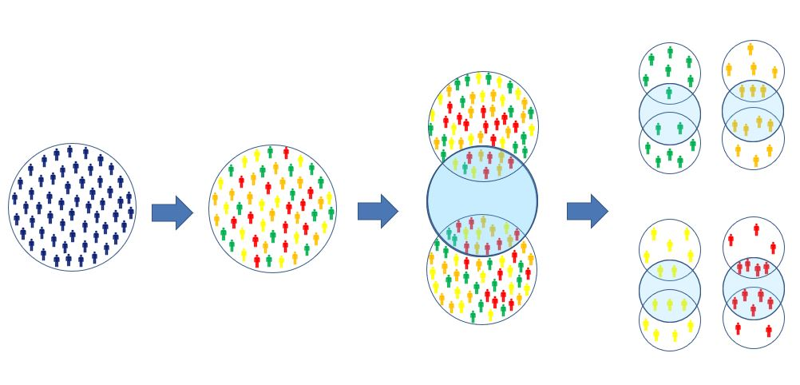

## Applications

*Hypertension*

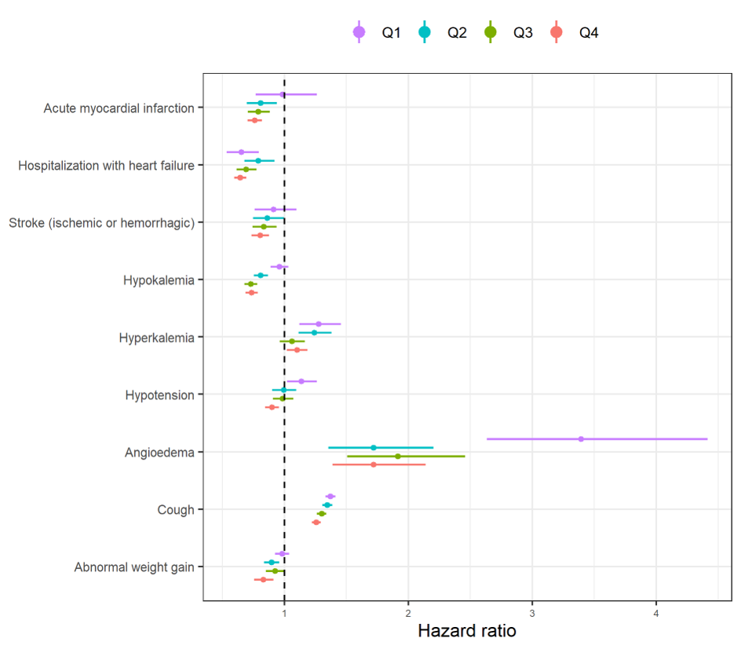

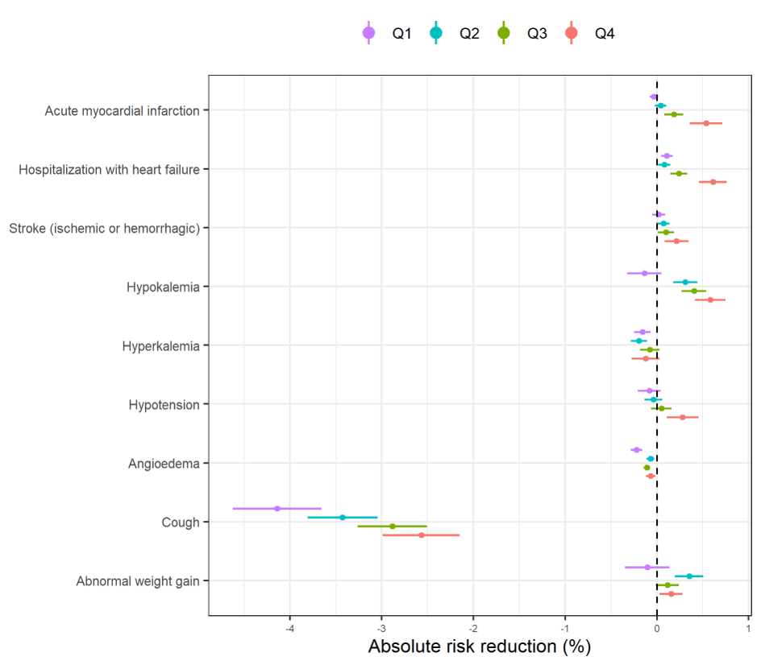

## Applications

*Osteoporosis*

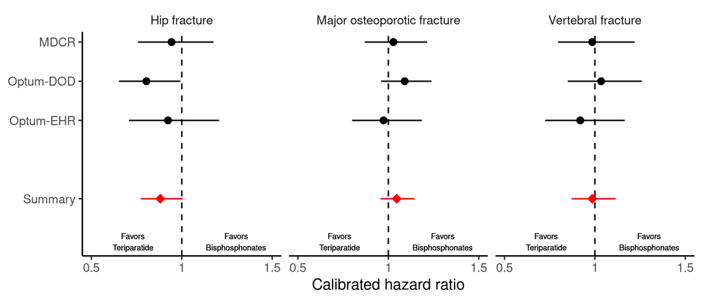

## Applications

*Osteoporosis*

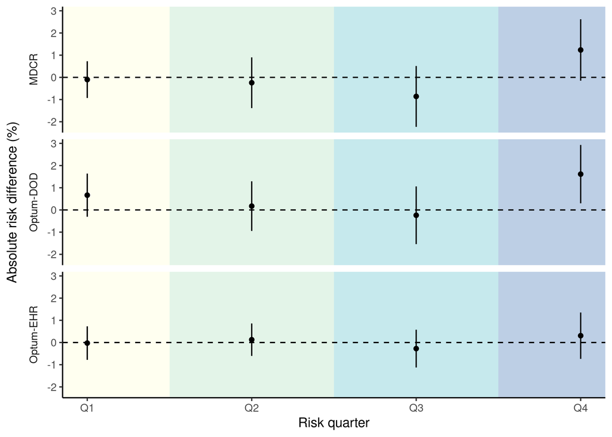

## Individualized approaches

- Stratification approach may not provide adequate prediction of benefit
- “Jumps” at cut-offs are not realistic
- Implement a risk-based smoothing approach

## Individualized approaches

Merging treatment arms, we develop prediction models including a constant relative treatment effect: \[E\{y| x,T\} = P(y| x, T) = f(\alpha+\beta_1x_1+\dots+\beta_px_p+\gamma_0 T)\] Individualized predictions are derived setting \(T=0\).

\[ f_{benefit}(lp | x, \hat{\beta}) = f_{smooth}(lp | x, \hat{\beta},T=0) - f_{smooth}(lp | x, \hat{\beta}, T=1) \]

## Individualized approaches

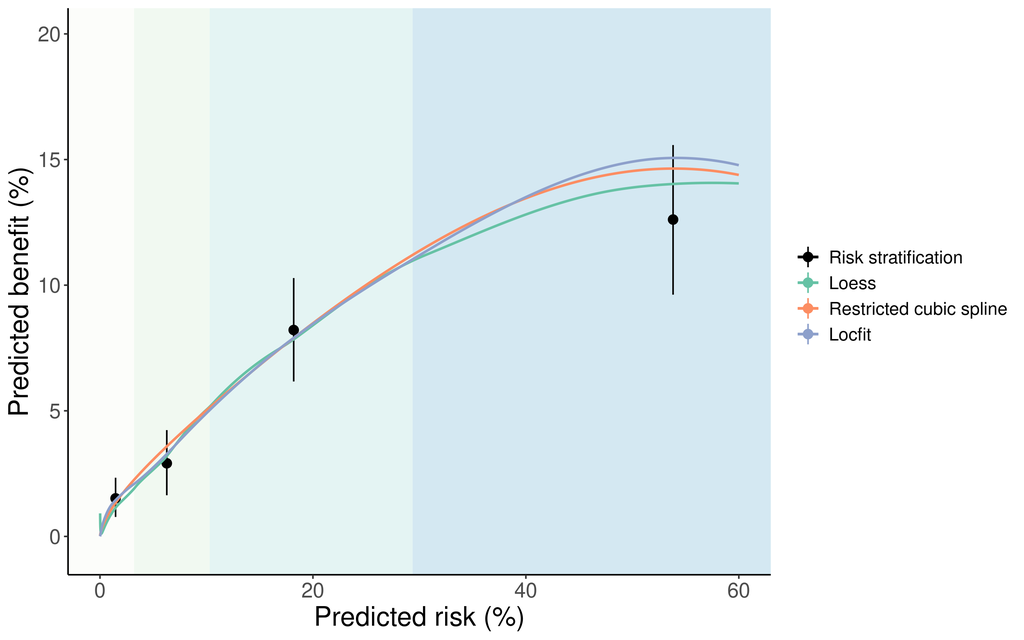